# Stack-Questions Analysis

Kyle MacDonald

11/6/2016

Load data. This is organized as three tables:

- Questions contains the title, body, creation date, score, and owner ID for each R question.
- Answers contains the body, creation date, score, and owner ID for each of the answers to these questions. The ParentId column links back to the Questions table.
- Tags contains the tags on each question besides the R tag.

Add year, month, and day columns using the date-time variable.

```r
questions %<>%
  mutate(yr = year(CreationDate),
         mon = month(CreationDate),
         dy = day(CreationDate))
```

### Descriptives and sanity checks

```r
n.users <- questions %>%
  select(OwnerUserId) %>%
  unique() %>%
  count()

n.questions <- nrow(questions)
```

There are 46068 unique users and 147075 questions in the dataset.

### Score analysis

What is the distribution over the *Score* variable?

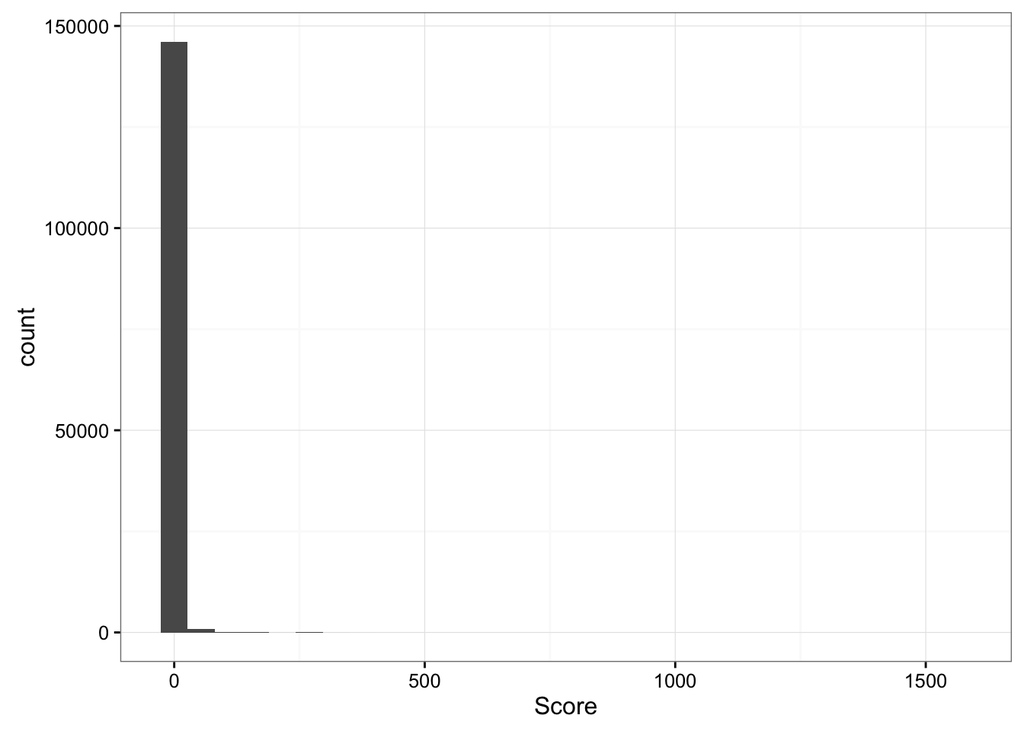

```r
ggplot(aes(x = Score), data = questions) +
  geom_histogram()
```

Looks like there are a couple of extreme values here, preventing us from getting a feel for the distribution. We can filter scores that are greater than +/- 2SD from the mean of score.

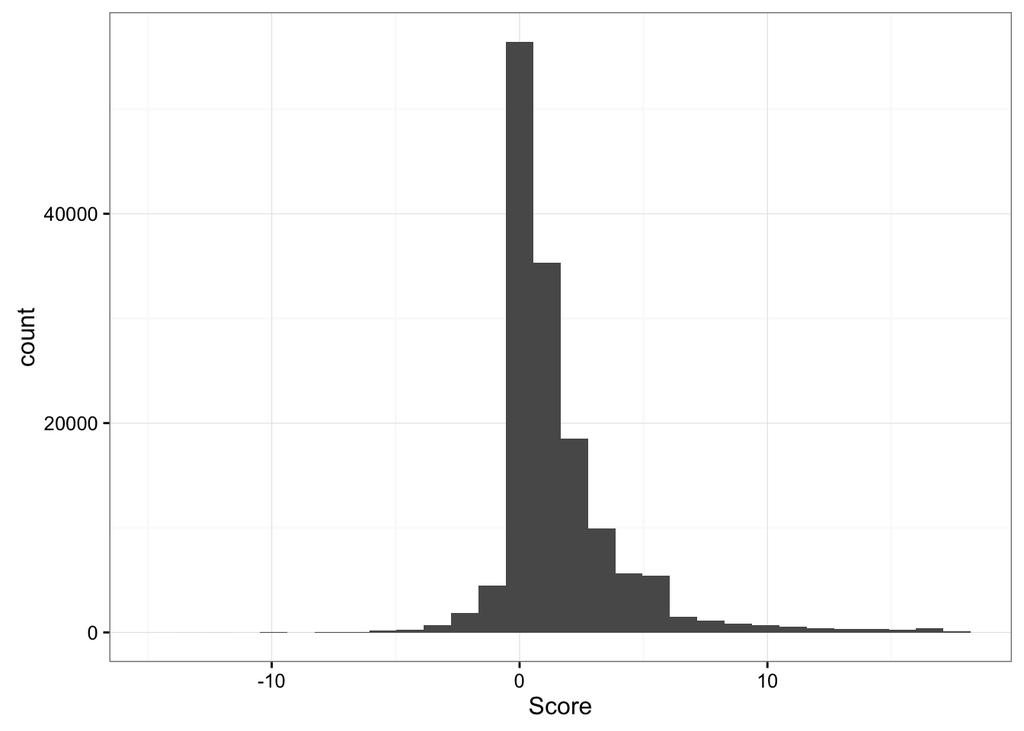

```r
q.filt <- questions %>%
  filter(Score <= mean(Score) + 2*sd(Score),
         Score >= mean(Score) - 2*sd(Score),
         year(CreationDate) > 2008)

ggplot(aes(x = Score), data = q.filt) +
  geom_histogram(bins = 30)
```

This distribution looks more reasonable. But what does it mean to get negative score? Let’s look at a small sample of the questions with the lowest scores to see what’s going on.

```r
worst.qs <- questions %>%
  select(Score, Body) %>%
  arrange(Score) %>%
  head(n=5)
```

```r
best.qs <- questions %>%
  select(Score, Body) %>%
  arrange(desc(Score)) %>%
  head(n=5)
```

TODO: figure out the best way to render the html in the Body variable.

### User analysis

What is the distribution of questions over users? First we compute some basic descriptives.

```r
ss.qs <- q.filt %>%
  filter(is.na(OwnerUserId) == F) %>%
  group_by(OwnerUserId) %>%
  summarise(count = n(),
            mean_score = mean(Score),
            med_score = median(Score))

q.sum <- summary(ss.qs$count)
```

The average number of questions per user is 3.145. The min is 1 (makes sense) and the max is 338 (wow, that’s a lot of questions!).

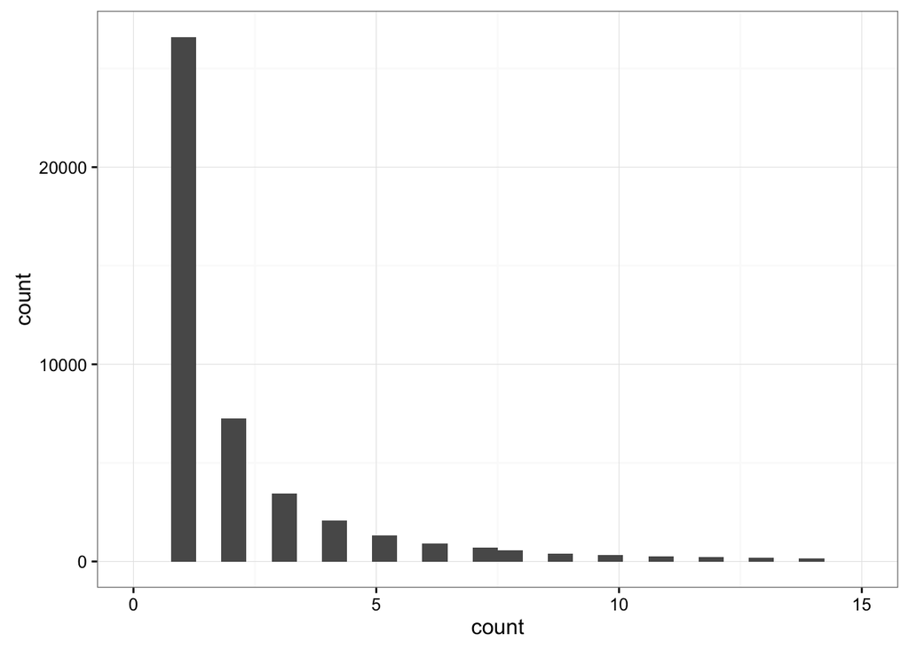

```r
ggplot(aes(x = count), data = ss.qs) +
  geom_histogram() +
  xlim(0,15)
```

### Analyze the most prolific question-asker

```r
max.q.id <- ss.qs %>%
  filter(count == summary(ss.qs$count)["Max."]) %>%
  select(OwnerUserId) %>%
  as.character()

ss.max <- questions %>%
  filter(OwnerUserId == max.q.id)
```

Plot this user’s question scores over time.

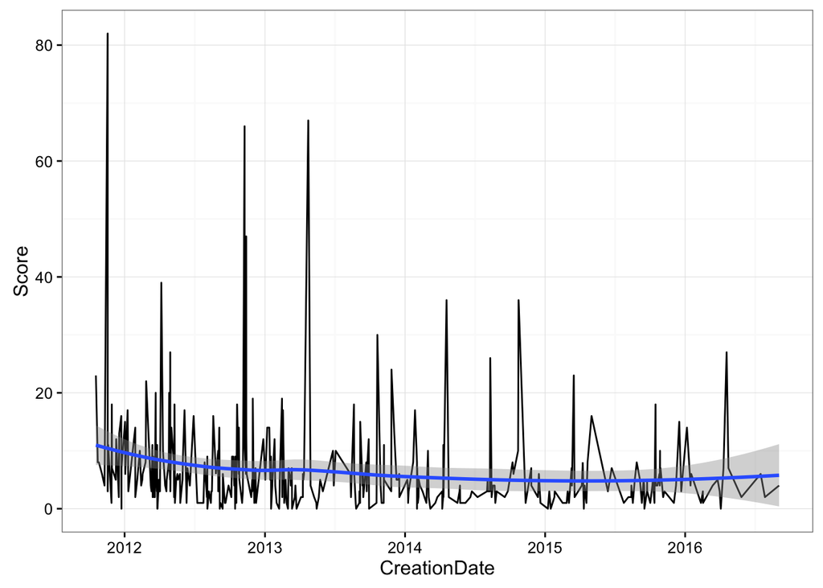

```r
ggplot(aes(x = CreationDate, y = Score), data = ss.max) +
  geom_line() +
  geom_smooth(method = "loess")
```

Hmm, not much of a change in Score over time. So maybe this user was always good at asking questions?

Their mean question score is 6.4901961 which is higher than mean for the group: 1.0203024

Now I’m curious about the distribution of average question scores over users.

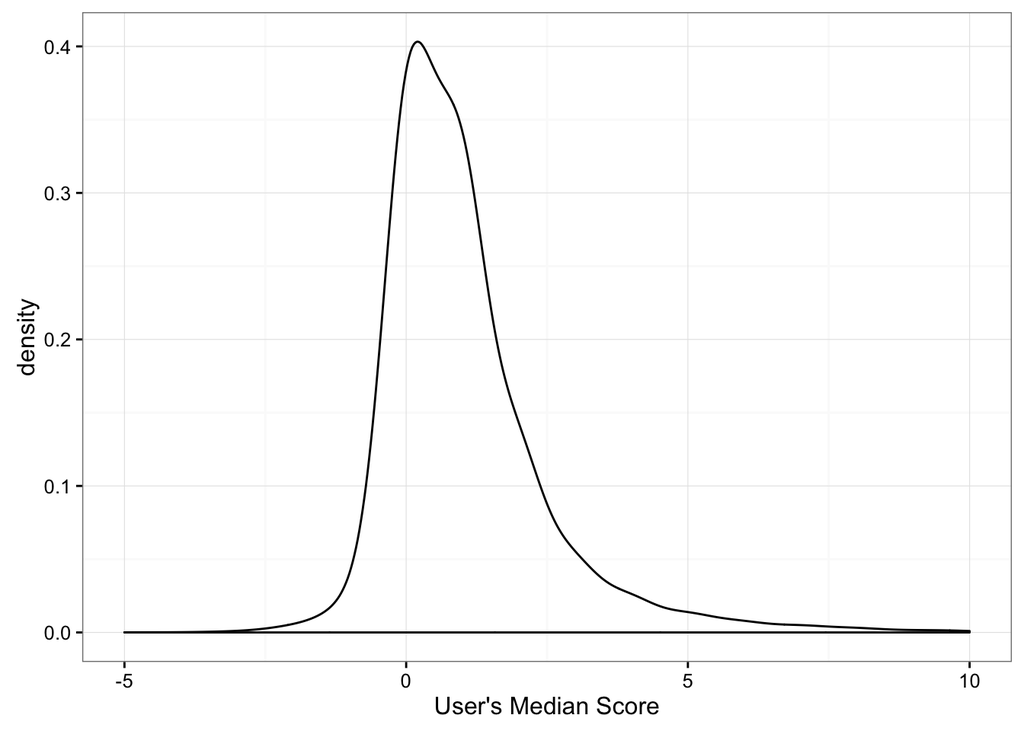

```r
ggplot(aes(x = med_score), data = filter(ss.qs, count > 1)) +
  geom_density(adjust = 3) +
  xlim(-5, 10) +
  labs(x = "User's Median Score")
```

### Has question quality changed over time?

Since there is so much data I’m going to subset to just the last two years.

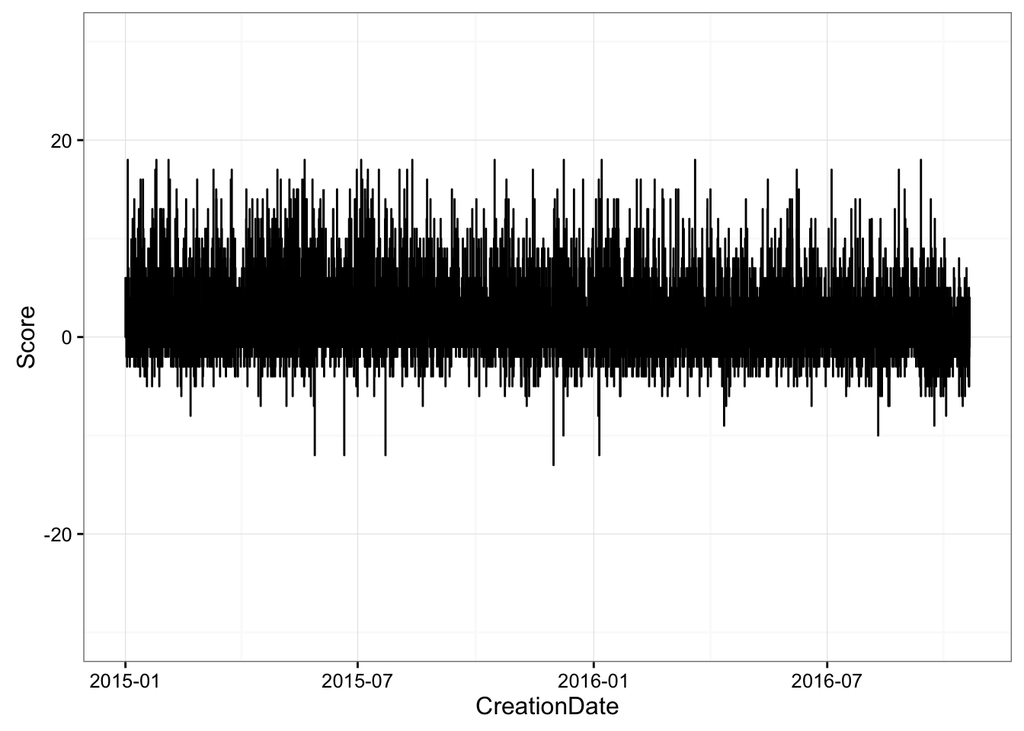

```r
q.filt %>%
  filter(year(CreationDate) >= 2015) %>%
  ggplot(aes(x = CreationDate, y = Score), data = .) +
  geom_line() +
  ylim(-30, 30)
```

```r
ci.fun <- function(df, column_name, threshold = 0.975) {
  data_vec <- df[[column_name]]
  # get the mean, standard deviation, and sample size
  m <- mean(data_vec, na.rm=T)
  stdev <- sd(data_vec, na.rm=T)
  n <- length(data_vec)
  # compute 95% ci bounds
  ci_bound_upper <- m + qnorm(threshold)*stdev/sqrt(n)
  ci_bound_lower <- m - qnorm(threshold)*stdev/sqrt(n)

  df %<>%
    mutate(m = m,
           ci_upper = ci_bound_upper,
           ci_lower = ci_bound_lower,
           n = n) %>%
    select(y, n, m:ci_lower) %>%
    unique()
  return(df)
}
```

```r
q.agg <- q.filt %>%
  group_by(y = year(CreationDate)) %>%
  do(ci.fun(df = ., column_name = "Score", threshold = 0.975))
```

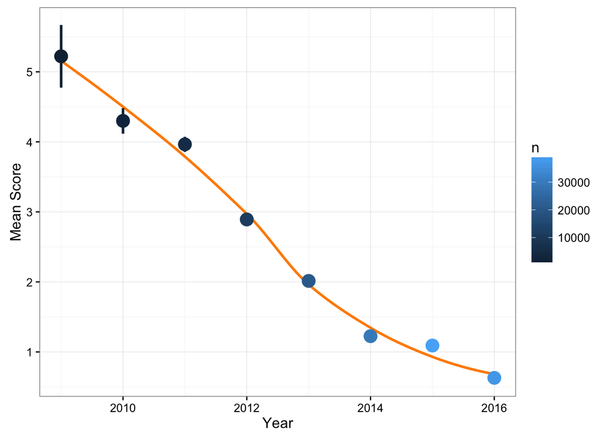

```r
ggplot(aes(x = y, y = m, color = n), data = q.agg) +
  geom_smooth(method = "loess", se = F, color = "darkorange") +
  geom_pointrange(aes(ymin = ci_lower, ymax = ci_upper), size = 1) +
  labs(
    x = "Year",
    y = "Mean Score"
  )
```

### How has the number of questions about R changed over time?

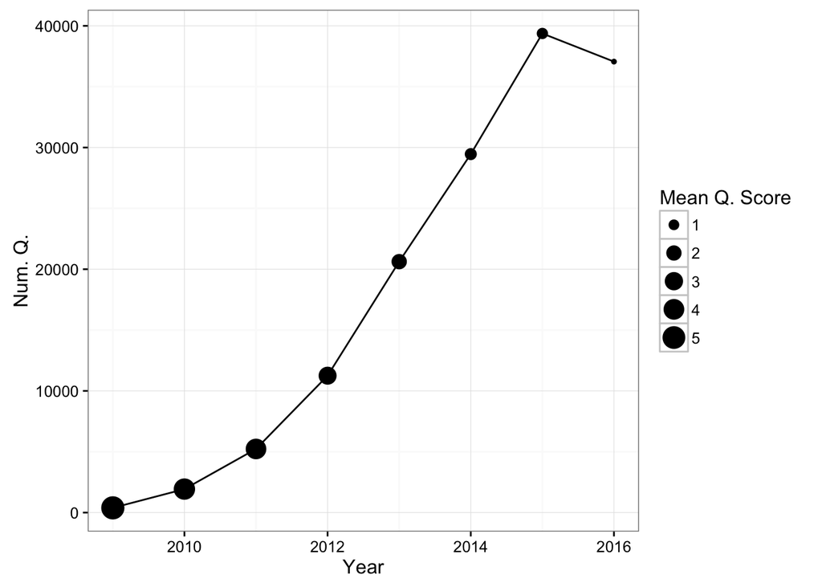

```r
q.filt %>%
  group_by(y = year(CreationDate)) %>%
  summarise(n = n(),
            m.score = mean(Score, na.rm = T)) %>%
  ggplot(aes(x = y, y = n)) +
  geom_line() +
  geom_point(aes(size = m.score)) +
  labs(
    x = "Year",
    y = "Num. Q.",
    size = "Mean Q. Score"
  )
```

### Any information in the question title?

Compute the length of the title for each question.

```r
q.filt %<>%
  mutate(title_length = str_length(Title),
         log_title_length = log(title_length),
         question_length = str_length(Body),
         log_question_length = log(question_length))
```

What’s the relationship between title length and question score? Since we have so much data, we are going to aggreate to get the average title length for each Score.

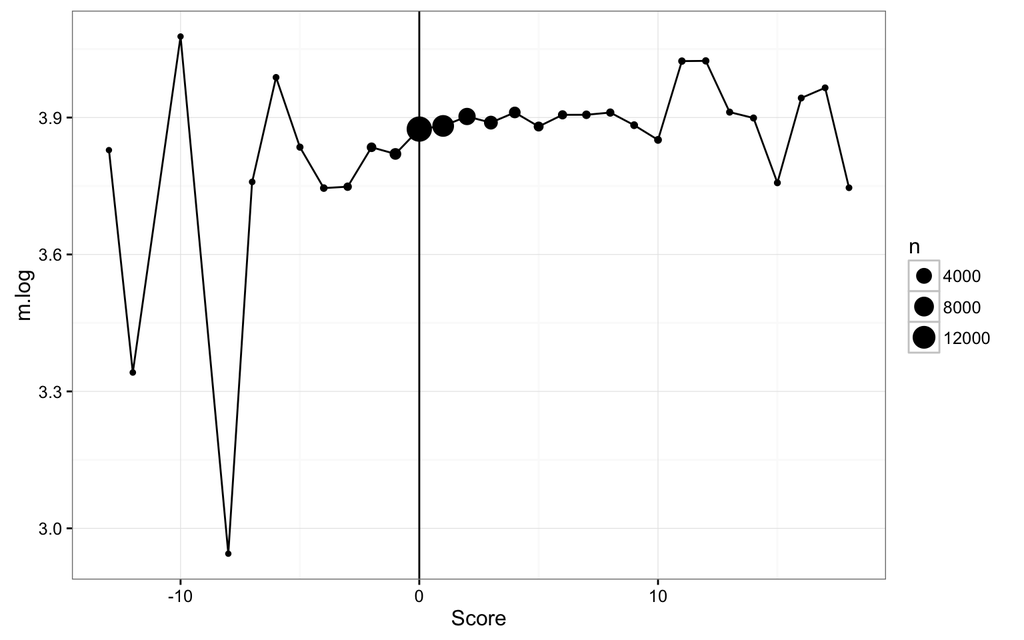

```r
q.filt %>%
  ungroup() %>%
  filter(year(CreationDate) == 2015) %>%
  group_by(Score) %>%
  summarise(m.log = mean(log_title_length),
            n = n()) %>%
  ggplot(aes(x = Score, y = m.log)) +
  geom_point(aes(size = n)) +
  geom_line() +
  geom_vline(xintercept = 0)
```

## NLP over Body of question

First we need to separate the code from the natural language.

Then we can do NLP to the natural language to see if any features of the questions predict better scores.

What proportion of the questions contain code?

```r
q.filt %<>% mutate(q_has_code = str_detect(Body, "<code>"))
```

```r
q.filt %>%
  group_by(q_has_code) %>%
  summarise(prop = round(n() / nrow(.), 2)) %>%
  kable()
```

| q_has_code | prop |
| --- | --- |
| FALSE | 0.08 |
| TRUE | 0.92 |

Most of the questions have code in them, which is nice to know. Does having code in your question lead to a higher question score?

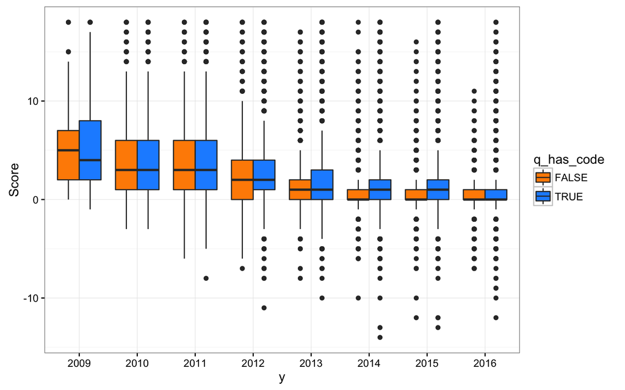

```r
q.filt %>%
  mutate(y = as.factor(year(CreationDate))) %>%
  ggplot(aes(x = y, y = Score, fill = q_has_code)) +
  geom_boxplot() +
  scale_fill_manual(values = c("darkorange", "dodgerblue"))
```

Hmm, a few things to note: First, you can see the overall decline in question scores over time, which I think just reflects how long the question has been available on Stack Overflow. Second, question scores are mostly between 0-4, but there are lots of outliers, especially in the more recent years. Third, there are no extreme negative scores until 2010/2011. And fourth, I’m not sure we should be modeling Score as a continous outcome, but I’m hesistant to “lose information” by converting it to a categorical variable.

### Question “body” analyses

```r
q.body <- q.filt %>%
  filter(year(CreationDate) > 2008,
         is.na(question_length) == F) %>%
  filter(question_length <= mean(question_length) + (2 * sd(question_length)))
```

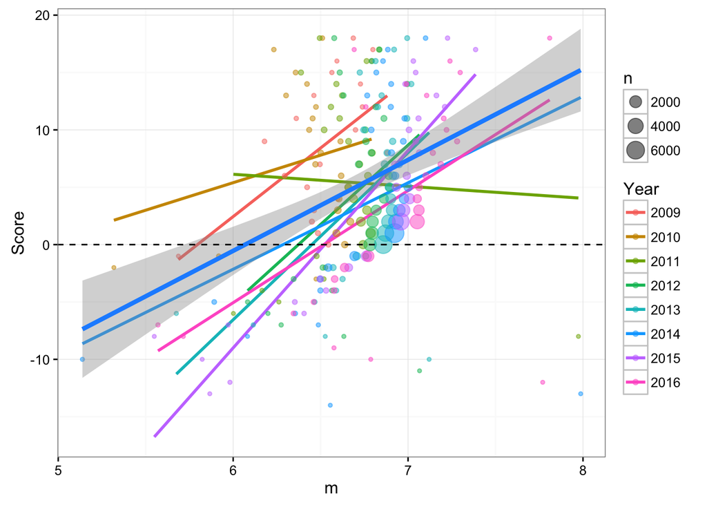

```r
q.body %>%
  group_by(Score, yr = year(CreationDate)) %>%
  summarise(m = mean(log_question_length, na.rm=T),
            n = n()) %>%
  ungroup() %>%
  filter(n >= mean(n) - (3 * sd(n)),
         n <= mean(n) + (3 * sd(n))) %>%
  ggplot(aes(x = m, y = Score, color = as.factor(yr))) +
  geom_smooth(method = "lm", se = F, linetype = "solid", alpha = 0.2) +
  geom_point(aes(size = n), alpha = 0.5) +
  geom_smooth(aes(x = m, y = Score), method = "lm", se = T,
              inherit.aes = F, color = "dodgerblue", size = 1.5) +
  geom_hline(yintercept = 0, linetype = "dashed") +
  labs(color = "Year")
```

Question length seems to be the first evidence of something that predicts score. But we should really be plotting the raw data (on the log scale):

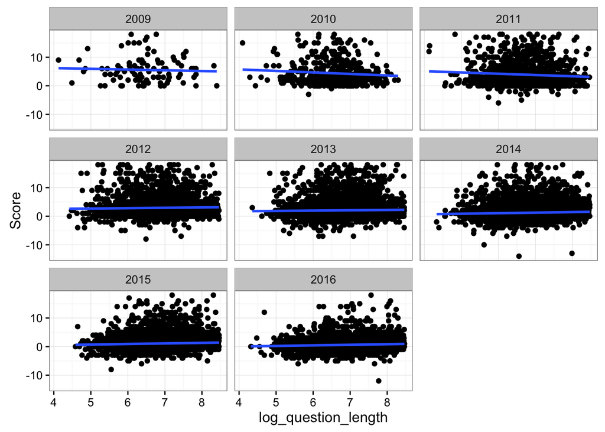

```r
q.body %>%
  sample_n(size = 0.25 * nrow(.)) %>%
  ggplot(aes(x = log_question_length, y = Score)) +
  geom_point() +
  facet_wrap(~yr) +
  geom_smooth(method = "lm", se = F)
```

Interesting. When I plot the raw data, it’s looks like there is no relationship between question length and Score.

Let’s quantify this relationship using a linear mixed effects model.

```r
m1 <- lmer(Score ~ log_question_length * log_title_length * q_has_code +
             (1|OwnerUserId),
           data = q.body)
```

```r
broom::tidy(m1) %>% kable(digits = 5)
```

| term | estimate | std.error | statistic | group |
| --- | --- | --- | --- | --- |
| (Intercept) | 10.05406 | 2.05345 | 4.89617 | fixed |
| log_question_length | -1.27879 | 0.33209 | -3.85078 | fixed |
| log_title_length | -2.15567 | 0.52926 | -4.07297 | fixed |
| q_has_codeTRUE | -7.97188 | 2.18488 | -3.64865 | fixed |
| log_question_length:log_title_length | 0.30765 | 0.08538 | 3.60315 | fixed |
| log_question_length:q_has_codeTRUE | 1.14480 | 0.34883 | 3.28182 | fixed |
| log_title_length:q_has_codeTRUE | 1.92030 | 0.56319 | 3.40969 | fixed |
| log_question_length:log_title_length:q_has_codeTRUE | -0.27098 | 0.08969 | -3.02117 | fixed |
| sd_(Intercept).OwnerUserId | 0.97468 | NA | NA | OwnerUserId |
| sd_Observation.Residual | 2.25826 | NA | NA | Residual |

Hmm, some significant terms here, but it’s hard to interpret what coeficients on the log scale, so let’s convert them back to the question/title length scale in characters.

```r
broom::tidy(m1) %>%
  mutate(char_scale = exp(estimate)) %>%
  kable(digits = 5)
```

| term | estimate | std.error | statistic | group | char_scale |
| --- | --- | --- | --- | --- | --- |
| (Intercept) | 10.05406 | 2.05345 | 4.89617 | fixed | 23249.92275 |
| log_question_length | -1.27879 | 0.33209 | -3.85078 | fixed | 0.27837 |
| log_title_length | -2.15567 | 0.52926 | -4.07297 | fixed | 0.11583 |
| q_has_codeTRUE | -7.97188 | 2.18488 | -3.64865 | fixed | 0.00035 |
| log_question_length:log_title_length | 0.30765 | 0.08538 | 3.60315 | fixed | 1.36022 |
| log_question_length:q_has_codeTRUE | 1.14480 | 0.34883 | 3.28182 | fixed | 3.14182 |
| log_title_length:q_has_codeTRUE | 1.92030 | 0.56319 | 3.40969 | fixed | 6.82302 |
| log_question_length:log_title_length:q_has_codeTRUE | -0.27098 | 0.08969 | -3.02117 | fixed | 0.76263 |
| sd_(Intercept).OwnerUserId | 0.97468 | NA | NA | OwnerUserId | 2.65032 |
| sd_Observation.Residual | 2.25826 | NA | NA | Residual | 9.56646 |